# Bayesian modeling and prediction for movies

Vicken Asadourian

## Setup

### Load packages

```r
library(ggplot2)
library(dplyr)
library(statsr)
library(BAS)
library(MASS)
library(GGally)
library(gridExtra)
```

### Load data

```r
load("movies.Rdata")
```

## Part 0: Intro

This project is a bayesian analysis of movie data. We’ll build linear models to predict the audience score of a film.

## Part 1: Data

The dataset is comprised of 651 randomly sampled movies produced and released before 2016. The data draws from APIs from imdb.com, rottentomatoes.com, and flixster.com. As this is random sampling, only correlations can be drawn. Because of the randomness of the selection and the size of the dataset, our results can be generalizable. Since this project is present through an English-speaking platform, and as the data is drawn from sources that are based in the English-speaking world and cater to English speakers, the data will be biased toward movies where English is the main language. This precludes many foreign films, such as Asian films or Indian films. * * *

## Part 2: Data manipulation

We are first going to create some new variables to aid in our exploratory data analysis. Below is a summary of the new variables.

`feature_film`: “yes” if `title_type` is Feature Film, “no” otherwise.

`drama`: “yes” if `genre` is Drama, “no” otherwise runtime.

`mpaa_rating_R`: “yes” if `mpaa_rating` is R, “no” otherwise

`oscar_season`: “yes” if movie is released in November, October, or December (based on `thtr_rel_month`), “no” otherwise.

`summer_season`: “yes” if movie is released in May, June, July, or August (based on `thtr_rel_month`), “no” otherwise.

```r
movies <- movies %>%
  mutate(feature_film = ifelse(title_type == "Feature Film", "yes", "no"),
         drama = ifelse(genre == "Drama", "yes", "no"),
         mpaa_rating_R = ifelse(mpaa_rating == "R","yes","no"),
         oscar_season = ifelse(thtr_rel_month == 11 | thtr_rel_month == 10 | thtr_rel_month == 12, "yes", "no"),
         summer_season = ifelse(thtr_rel_month == 5 | thtr_rel_month == 6 | thtr_rel_month == 7 | thtr_rel_month == 8, "yes","no"))
```

```r
movies2_features <- c("audience_score", "feature_film", "drama", "runtime", "mpaa_rating_R", "thtr_rel_year", "oscar_season", "summer_season", "imdb_rating", "imdb_num_votes", "critics_score", "best_pic_nom", "best_pic_win", "best_actor_win", "best_actress_win", "best_dir_win", "top200_box")
movies2 <- movies[movies2_features]
```

## Part 3: Exploratory data analysis

We’ll start out at a higher, broader level by taking a look at a summary of the variables in movies2.

```r
summary(movies2)
```

```
##  audience_score  feature_film          drama              runtime
##  Min.   :11.00   Length:651         Length:651         Min.   : 39.0
##  1st Qu.:46.00   Class :character   Class :character   1st Qu.: 92.0
##  Median :65.00   Mode  :character   Mode  :character   Median :103.0
##  Mean   :62.36                                         Mean   :105.8
##  3rd Qu.:80.00                                         3rd Qu.:115.8
##  Max.   :97.00                                         Max.   :267.0
##                                                        NA's   :1
##  mpaa_rating_R      thtr_rel_year  oscar_season       summer_season
##  Length:651         Min.   :1970   Length:651         Length:651
##  Class :character   1st Qu.:1990   Class :character   Class :character
##  Mode  :character   Median :2000   Mode  :character   Mode  :character
##                     Mean   :1998
##                     3rd Qu.:2007
##                     Max.   :2014
##
##   imdb_rating    imdb_num_votes   critics_score    best_pic_nom
##  Min.   :1.900   Min.   :   180   Min.   :  1.00   no :629
##  1st Qu.:5.900   1st Qu.:  4546   1st Qu.: 33.00   yes: 22
##  Median :6.600   Median : 15116   Median : 61.00
##  Mean   :6.493   Mean   : 57533   Mean   : 57.69
##  3rd Qu.:7.300   3rd Qu.: 58300   3rd Qu.: 83.00
##  Max.   :9.000   Max.   :893008   Max.   :100.00
##
##  best_pic_win best_actor_win best_actress_win best_dir_win top200_box
##  no :644      no :558        no :579          no :608      no :636
##  yes:  7      yes: 93        yes: 72          yes: 43      yes: 15
##
##
##
##
##
```

This summary gives us a look at the spread of each variable.

Let’s also take a look at the levels of each variable.

```r
str(movies2)
```

```
## Classes 'tbl_df', 'tbl' and 'data.frame':    651 obs. of  17 variables:
##  $ audience_score  : num  73 81 91 76 27 86 76 47 89 66 ...
##  $ feature_film    : chr  "yes" "yes" "yes" "yes" ...
##  $ drama           : chr  "yes" "yes" "no" "yes" ...
##  $ runtime         : num  80 101 84 139 90 78 142 93 88 119 ...
##  $ mpaa_rating_R   : chr  "yes" "no" "yes" "no" ...
##  $ thtr_rel_year   : num  2013 2001 1996 1993 2004 ...
##  $ oscar_season    : chr  "no" "no" "no" "yes" ...
##  $ summer_season   : chr  "no" "no" "yes" "no" ...
##  $ imdb_rating     : num  5.5 7.3 7.6 7.2 5.1 7.8 7.2 5.5 7.5 6.6 ...
##  $ imdb_num_votes  : int  899 12285 22381 35096 2386 333 5016 2272 880 12496 ...
##  $ critics_score   : num  45 96 91 80 33 91 57 17 90 83 ...
##  $ best_pic_nom    : Factor w/ 2 levels "no","yes": 1 1 1 1 1 1 1 1 1 1 ...
##  $ best_pic_win    : Factor w/ 2 levels "no","yes": 1 1 1 1 1 1 1 1 1 1 ...
##  $ best_actor_win  : Factor w/ 2 levels "no","yes": 1 1 1 2 1 1 1 2 1 1 ...
##  $ best_actress_win: Factor w/ 2 levels "no","yes": 1 1 1 1 1 1 1 1 1 1 ...
##  $ best_dir_win    : Factor w/ 2 levels "no","yes": 1 1 1 2 1 1 1 1 1 1 ...
##  $ top200_box      : Factor w/ 2 levels "no","yes": 1 1 1 1 1 1 1 1 1 1 ...
```

Let’s use boxplots to visualize how the newly-formed variables interact with `audience_score`.

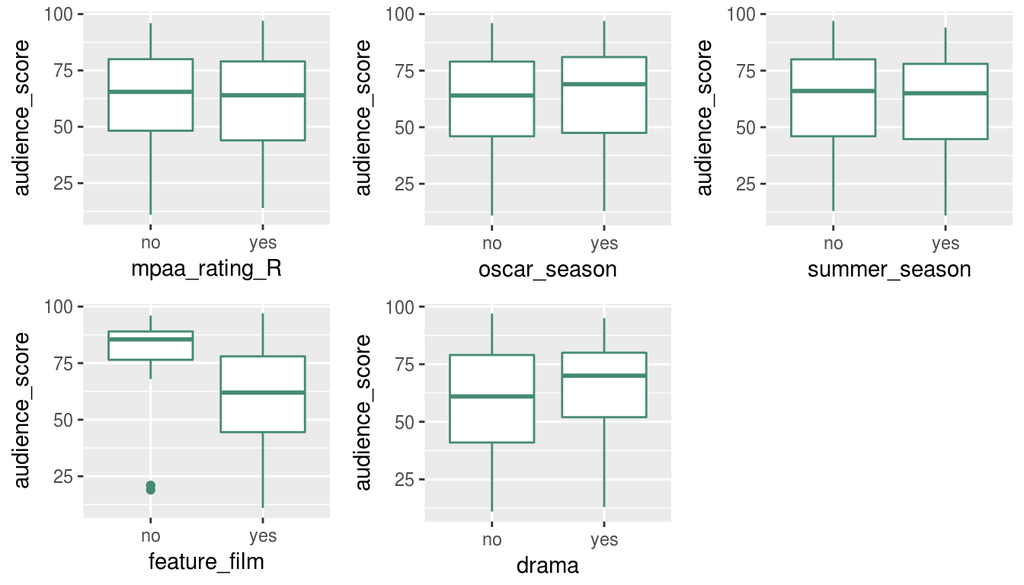

```r
plot1 <- ggplot(movies2, aes(x=mpaa_rating_R,y=audience_score))+
            geom_boxplot(colour="aquamarine4")

plot2 <- ggplot(movies2, aes(x=oscar_season, y=audience_score))+
            geom_boxplot(colour="aquamarine4")

plot3 <- ggplot(movies2, aes(x=summer_season,y=audience_score))+
            geom_boxplot(colour="aquamarine4")

plot4 <- ggplot(movies2, aes(x=feature_film, y=audience_score))+
            geom_boxplot(colour="aquamarine4")

plot5 <- ggplot(movies2, aes(x=drama, y=audience_score))+
            geom_boxplot(colour="aquamarine4")

grid.arrange(plot1,plot2,plot3,plot4,plot5, ncol=3)
```

We’ll then map out correlation charts that will show the relationships between `audience_score` and all other variables in `movies2`.

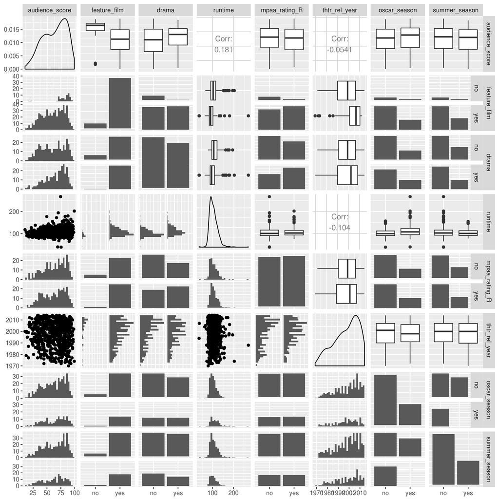

```r
suppressWarnings(suppressMessages(print(ggpairs(movies2, columns = 1:8))))
```

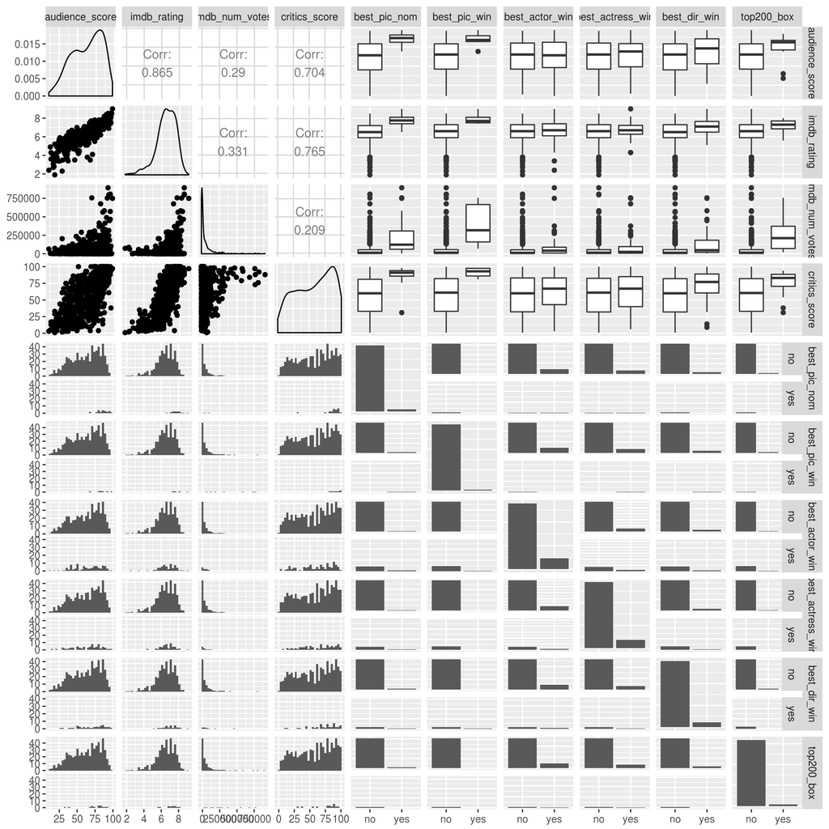

```r
suppressWarnings(suppressMessages(print(ggpairs(movies2, columns = c(1,9:17)))))
```

Notice the high correlation between `audience_score` and `critics_score`. Let’s visualize this correlation with a scatter plot with a regression line.

```r
cor(movies2$audience_score, movies2$critics_score)
```

```
## [1] 0.7042762
```

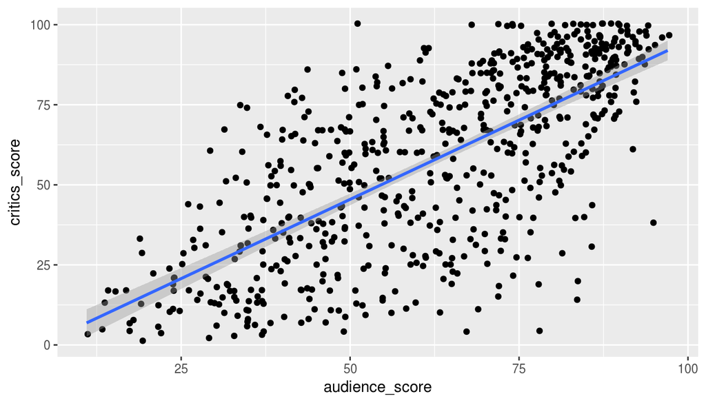

```r
ggplot(data=movies2, aes(x = audience_score, y = critics_score)) +
  geom_jitter() +
  geom_smooth(method = "lm")
```

Let’s do the same with `imdb_rating`, again due to the high correlation it has with `audience_score`.

```r
cor(movies2$audience_score, movies2$imdb_rating)
```

```
## [1] 0.8648652
```

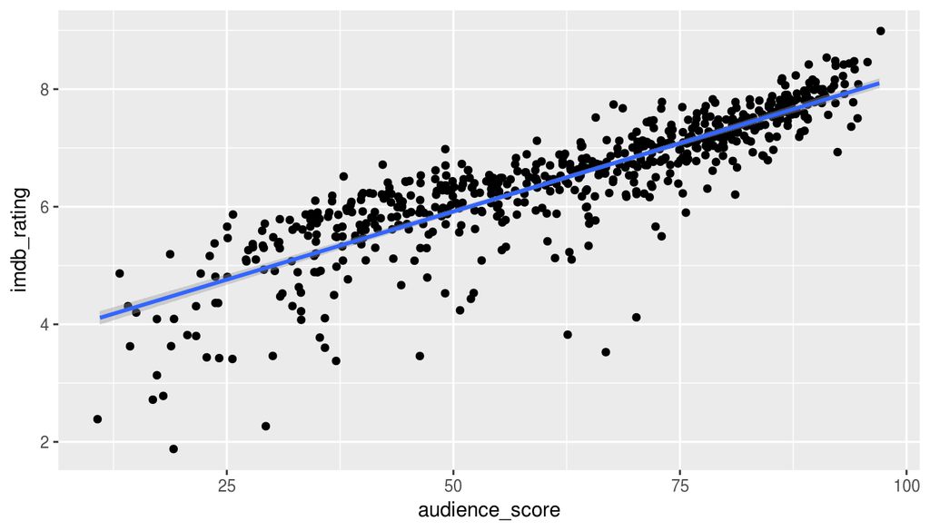

```r
ggplot(data=movies2, aes(x = audience_score, y = imdb_rating)) +
  geom_jitter() +
  geom_smooth(method = "lm")
```

We can see strong positive correlations with both sets of variables.

## Part 4: Modeling

We’ll first create the full linear model, incorporating every variables in `movies2`.

We will use the `stepAIC` function from library `MASS` to build a model (backwards) until the AIC can not be lowered.

```r
as_full <- lm(audience_score ~ ., data= na.omit(movies2))

as_full
```

```
##
## Call:
## lm(formula = audience_score ~ ., data = na.omit(movies2))
##
## Coefficients:
##         (Intercept)      feature_filmyes             dramayes
##           1.244e+02           -2.248e+00            1.292e+00
##             runtime     mpaa_rating_Ryes        thtr_rel_year
##          -5.614e-02           -1.444e+00           -7.657e-02
##     oscar_seasonyes     summer_seasonyes          imdb_rating
##          -5.333e-01            9.106e-01            1.472e+01
##      imdb_num_votes        critics_score      best_pic_nomyes
##           7.234e-06            5.748e-02            5.321e+00
##     best_pic_winyes    best_actor_winyes  best_actress_winyes
##          -3.212e+00           -1.544e+00           -2.198e+00
##     best_dir_winyes        top200_boxyes
##          -1.231e+00            8.478e-01
```

### Creating a model based on AIC

We will use the `stepAIC` function, tuned to optimize for AIC, to find the best model. The model will be built backwards.

```r
stepAIC.model <- stepAIC(as_full, direction = "backward", trace = TRUE)
```

```
## Start:  AIC=3006.94
## audience_score ~ feature_film + drama + runtime + mpaa_rating_R +
##     thtr_rel_year + oscar_season + summer_season + imdb_rating +
##     imdb_num_votes + critics_score + best_pic_nom + best_pic_win +
##     best_actor_win + best_actress_win + best_dir_win + top200_box
##
##                    Df Sum of Sq    RSS    AIC
## - top200_box        1         9  62999 3005.0
## - oscar_season      1        28  63018 3005.2
## - best_pic_win      1        48  63038 3005.4
## - best_dir_win      1        51  63040 3005.5
## - summer_season     1        92  63081 3005.9
## - best_actor_win    1       171  63160 3006.7
## - feature_film      1       177  63166 3006.8
## <none>                           62990 3006.9
## - drama             1       216  63206 3007.2
## - imdb_num_votes    1       255  63244 3007.6
## - best_actress_win  1       283  63273 3007.9
## - mpaa_rating_R     1       314  63304 3008.2
## - thtr_rel_year     1       397  63386 3009.0
## - best_pic_nom      1       408  63398 3009.1
## - runtime           1       538  63527 3010.5
## - critics_score     1       669  63659 3011.8
## - imdb_rating       1     58556 121545 3432.2
##
## Step:  AIC=3005.04
## audience_score ~ feature_film + drama + runtime + mpaa_rating_R +
##     thtr_rel_year + oscar_season + summer_season + imdb_rating +
##     imdb_num_votes + critics_score + best_pic_nom + best_pic_win +
##     best_actor_win + best_actress_win + best_dir_win
##
##                    Df Sum of Sq    RSS    AIC
## - oscar_season      1        26  63025 3003.3
## - best_pic_win      1        49  63047 3003.5
## - best_dir_win      1        52  63051 3003.6
## - summer_season     1        94  63093 3004.0
## - best_actor_win    1       169  63168 3004.8
## - feature_film      1       176  63175 3004.8
## <none>                           62999 3005.0
## - drama             1       214  63213 3005.2
```

[output cut: 127 more lines]

```
##
## Step:  AIC=2998.81
## audience_score ~ runtime + mpaa_rating_R + thtr_rel_year + imdb_rating +
##     critics_score + best_pic_nom + best_actor_win + best_actress_win
##
##                    Df Sum of Sq    RSS    AIC
## <none>                           63757 2998.8
## - thtr_rel_year     1       201  63958 2998.9
## - best_actor_win    1       219  63976 2999.0
## - best_actress_win  1       266  64023 2999.5
## - mpaa_rating_R     1       367  64124 3000.5
## - best_pic_nom      1       442  64199 3001.3
## - runtime           1       519  64276 3002.1
## - critics_score     1       879  64635 3005.7
## - imdb_rating       1     67356 131113 3465.4
```

The final model built using AIC consists of the following variables:

```r
AIC.lm <- lm(audience_score ~ runtime + mpaa_rating_R + thtr_rel_year + imdb_rating + critics_score + best_pic_nom + best_actor_win + best_actress_win, data=movies2)
```

Taking a look at the coefficients of this model:

```r
AIC.lm$coefficients
```

```
##         (Intercept)             runtime    mpaa_rating_Ryes
##         70.10675281         -0.05115515         -1.50528039
##       thtr_rel_year         imdb_rating       critics_score
##         -0.05122557         15.00149242          0.06409989
##     best_pic_nomyes   best_actor_winyes best_actress_winyes
##          4.88277038         -1.73481942         -2.11568281
```

Taking a look at the standard deviation of the model:

```r
summary(AIC.lm)$sigma
```

```
## [1] 9.973201
```

```r
#plot(movies2$audience_score ~ AIC.lm$residuals)
```

Plotting the residuals of the model:

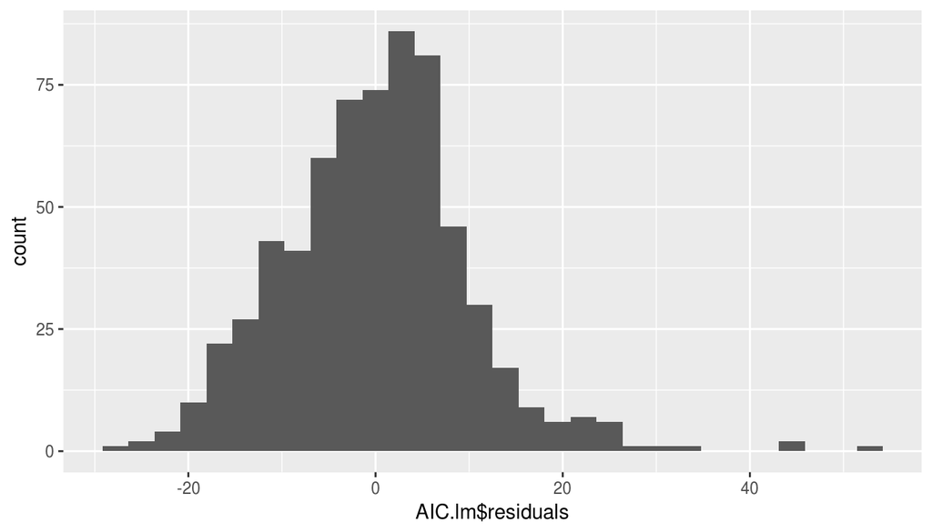

```r
ggplot(data=AIC.lm, aes(x=AIC.lm$residuals)) + geom_histogram()
```

We can see that the residuals are normally distributed.

### Creating a model based on BIC

We will use the `stepAIC` function, tuned to optimize for BIC, to find the best model. The model will be built backwards.

```r
stepBIC.model <- stepAIC(as_full, direction = "backward", k=log(nrow(movies2)), trace = TRUE)
```

```
## Start:  AIC=3083.07
## audience_score ~ feature_film + drama + runtime + mpaa_rating_R +
##     thtr_rel_year + oscar_season + summer_season + imdb_rating +
##     imdb_num_votes + critics_score + best_pic_nom + best_pic_win +
##     best_actor_win + best_actress_win + best_dir_win + top200_box
##
##                    Df Sum of Sq    RSS    AIC
## - top200_box        1         9  62999 3076.7
## - oscar_season      1        28  63018 3076.9
## - best_pic_win      1        48  63038 3077.1
## - best_dir_win      1        51  63040 3077.1
## - summer_season     1        92  63081 3077.5
## - best_actor_win    1       171  63160 3078.4
## - feature_film      1       177  63166 3078.4
## - drama             1       216  63206 3078.8
## - imdb_num_votes    1       255  63244 3079.2
## - best_actress_win  1       283  63273 3079.5
## - mpaa_rating_R     1       314  63304 3079.8
## - thtr_rel_year     1       397  63386 3080.7
## - best_pic_nom      1       408  63398 3080.8
## - runtime           1       538  63527 3082.1
## <none>                           62990 3083.1
## - critics_score     1       669  63659 3083.5
## - imdb_rating       1     58556 121545 3503.9
##
## Step:  AIC=3076.69
## audience_score ~ feature_film + drama + runtime + mpaa_rating_R +
##     thtr_rel_year + oscar_season + summer_season + imdb_rating +
##     imdb_num_votes + critics_score + best_pic_nom + best_pic_win +
##     best_actor_win + best_actress_win + best_dir_win
##
##                    Df Sum of Sq    RSS    AIC
## - oscar_season      1        26  63025 3070.5
## - best_pic_win      1        49  63047 3070.7
## - best_dir_win      1        52  63051 3070.8
## - summer_season     1        94  63093 3071.2
## - best_actor_win    1       169  63168 3072.0
## - feature_film      1       176  63175 3072.0
## - drama             1       214  63213 3072.4
## - best_actress_win  1       279  63278 3073.1
```

[output cut: 185 more lines]

```
##                 Df Sum of Sq    RSS    AIC
## - mpaa_rating_R  1       361  65126 3020.5
## - runtime        1       638  65403 3023.3
## <none>                        64765 3023.4
## - critics_score  1      1027  65792 3027.1
## - imdb_rating    1     68173 132937 3484.3
##
## Step:  AIC=3020.53
## audience_score ~ runtime + imdb_rating + critics_score
##
##                 Df Sum of Sq    RSS    AIC
## <none>                        65126 3020.5
## - runtime        1       653  65779 3020.5
## - critics_score  1      1073  66199 3024.7
## - imdb_rating    1     67874 133000 3478.2
```

The final model will use the following variables:

`audience_score ~ runtime + imdb_rating + critics_score`

```r
BIC.lm <- lm(audience_score ~ runtime + imdb_rating + critics_score, data=movies2)
```

```r
BIC.lm$coefficients
```

```
##   (Intercept)       runtime   imdb_rating critics_score
##  -33.28320569   -0.05361506   14.98076157    0.07035672
```

```r
summary(BIC.lm)$sigma
```

```
## [1] 10.04062
```

```r
#plot(na.omit(movies2$audience_score) ~ BIC.lm$residuals)
```

Taking a look at the residuals:

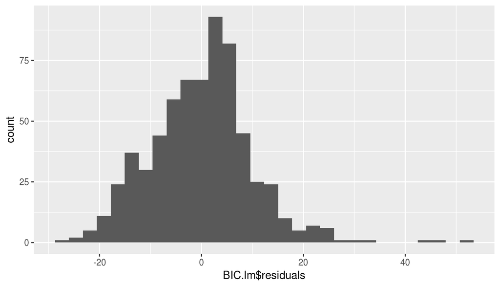

```r
ggplot(data=BIC.lm, aes(x=BIC.lm$residuals)) + geom_histogram()
```

We can see that the residuals are normally distributed.

### Creating a model using bayesian averaging

```r
as_full.bas <- bas.lm(audience_score ~ .,
       prior ="BIC",
       modelprior = uniform(),
       data = na.omit(movies2))

as_full.bas
```

```
##
## Call:
## bas.lm(formula = audience_score ~ ., data = na.omit(movies2),     prior = "BIC", modelprior = uniform())
##
##
##  Marginal Posterior Inclusion Probabilities:
##           Intercept      feature_filmyes             dramayes
##             1.00000              0.06537              0.04320
##             runtime     mpaa_rating_Ryes        thtr_rel_year
##             0.46971              0.19984              0.09069
##     oscar_seasonyes     summer_seasonyes          imdb_rating
##             0.07506              0.08042              1.00000
##      imdb_num_votes        critics_score      best_pic_nomyes
##             0.05774              0.88855              0.13119
##     best_pic_winyes    best_actor_winyes  best_actress_winyes
##             0.03985              0.14435              0.14128
##     best_dir_winyes        top200_boxyes
##             0.06694              0.04762
```

According to this model, there is a 100% chance that `imdb_rating` will be included in the final model. Other noteworthy variables are `runtime` (~47%), `critics_score` (~89%). The variable with the nearest score to these is `mpaa_rating_R:yes` at ~20%.

```r
confint(coef(as_full.bas))
```

```
##                            2.5  %      97.5  %          beta
## Intercept            6.155170e+01 6.307159e+01  6.234769e+01
## feature_filmyes     -8.959445e-01 3.437558e-03 -1.046908e-01
## dramayes             0.000000e+00 0.000000e+00  1.604413e-02
## runtime             -8.373987e-02 0.000000e+00 -2.567772e-02
## mpaa_rating_Ryes    -2.151377e+00 0.000000e+00 -3.036174e-01
## thtr_rel_year       -5.146392e-02 0.000000e+00 -4.532635e-03
## oscar_seasonyes     -9.125231e-01 1.027790e-03 -8.034940e-02
## summer_seasonyes    -9.777255e-03 1.107899e+00  8.704545e-02
## imdb_rating          1.367179e+01 1.653907e+01  1.498203e+01
## imdb_num_votes      -3.183043e-08 1.683218e-06  2.080713e-07
## critics_score        0.000000e+00 1.050434e-01  6.296648e-02
## best_pic_nomyes      0.000000e+00 5.011089e+00  5.068035e-01
## best_pic_winyes      0.000000e+00 0.000000e+00 -8.502836e-03
## best_actor_winyes   -2.525089e+00 0.000000e+00 -2.876695e-01
## best_actress_winyes -2.848626e+00 0.000000e+00 -3.088382e-01
## best_dir_winyes     -1.310904e+00 0.000000e+00 -1.195011e-01
## top200_boxyes        0.000000e+00 0.000000e+00  8.648185e-02
## attr(,"Probability")
## [1] 0.95
## attr(,"class")
## [1] "confint.bas"
```

```r
summary(as_full.bas)
```

```
##      Intercept feature_filmyes dramayes runtime mpaa_rating_Ryes
## [1,]         1               0        0       1                0
## [2,]         1               0        0       0                0
## [3,]         1               0        0       0                0
## [4,]         1               0        0       0                1
## [5,]         1               0        0       1                1
##      thtr_rel_year oscar_seasonyes summer_seasonyes imdb_rating
## [1,]             0               0                0           1
## [2,]             0               0                0           1
## [3,]             0               0                0           1
## [4,]             0               0                0           1
## [5,]             0               0                0           1
##      imdb_num_votes critics_score best_pic_nomyes best_pic_winyes
## [1,]              0             1               0               0
## [2,]              0             1               0               0
## [3,]              0             1               0               0
## [4,]              0             1               0               0
## [5,]              0             1               0               0
##      best_actor_winyes best_actress_winyes best_dir_winyes top200_boxyes
## [1,]                 0                   0               0             0
## [2,]                 0                   0               0             0
## [3,]                 1                   0               0             0
## [4,]                 0                   0               0             0
## [5,]                 0                   0               0             0
##             BF PostProbs     R2 dim   logmarg
## [1,] 1.0000000    0.1297 0.7549   4 -3615.279
## [2,] 0.9968489    0.1293 0.7525   3 -3615.282
## [3,] 0.2543185    0.0330 0.7539   4 -3616.648
## [4,] 0.2521327    0.0327 0.7539   4 -3616.657
## [5,] 0.2391994    0.0310 0.7563   5 -3616.710
```

The best model chosen contains the variables `runtime`, `imdb_rating`, and `critics_score`. Notice that this is the same model created by the backwards stepwise BIC method above.

Below, we can visualize the goodness of each of the models analyzed using the `bas.lm` function. The best model (rank 1) shows on the left, with the colored squares representing variables that would be selected for that particular model.

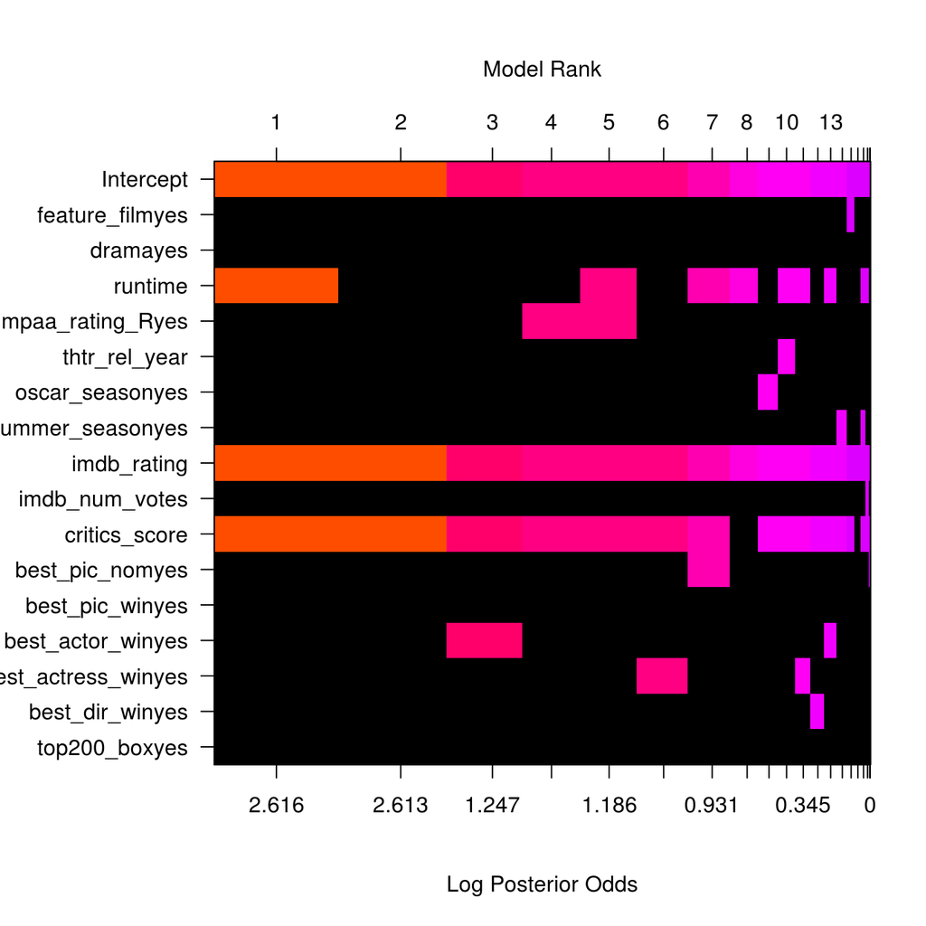

```r
image(as_full.bas, rotate = F)
```

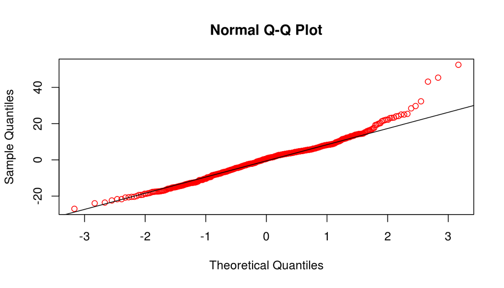

```r
qqnorm(BIC.lm$residuals, col="red")
qqline(BIC.lm$residuals)
```

We see a normal distribution here.

Now let’s plot the residuals against the fitted values.

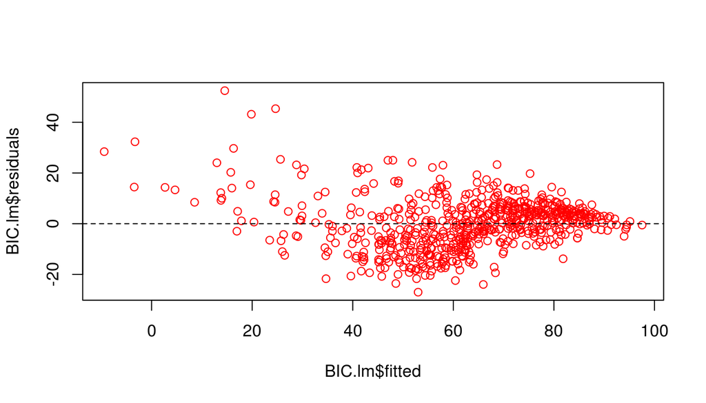

```r
plot(BIC.lm$residuals ~ BIC.lm$fitted, col="red")
abline(h=0, lty=2)
```

We see some left-skewness here, but the data is generally scattered around 0.

Now let’s plot the absolute value of the residuals against the fitted values.

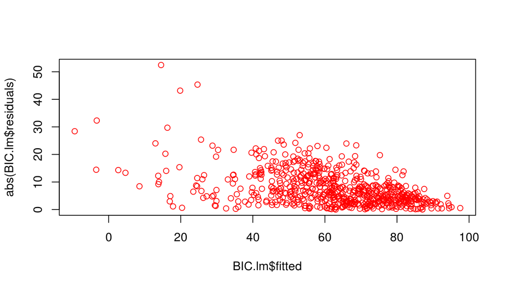

```r
plot(abs(BIC.lm$residuals) ~ BIC.lm$fitted, col="red")
```

We do not see a fan shape, meeting the necessary condition.

## Part 5: Prediction

The movie I’ve chosen is *Finding Dory*. The information I will be using for the prediction comes from:

[IMDB](http://www.imdb.com/title/tt2277860/) and [Rotten Tomatoes.](https://www.rottentomatoes.com/m/finding_dory)

I’ll create the data frames containing *Finding Dory*’s information.

```r
finding_dory_df <- data.frame(imdb_rating = 7.5, runtime = 97, critics_score = 94, mpaa_rating_R="no", thtr_rel_year=2016, best_pic_nom="no",best_actor_win="no", best_actress_win="no")
```

I will run predictions using both the BIC and AIC models, to contrast them. Note that the set of variables the BIC model uses is a subset of the variables the AIC model uses.

```r
predict(BIC.lm, newdata = finding_dory_df, interval = "prediction", level = 0.95)
```

```
##        fit      lwr      upr
## 1 80.48538 60.72202 100.2487
```

The BIC model predicts a score of 80.48538.

```r
predict(AIC.lm, newdata = finding_dory_df, interval = "prediction", level = 0.95)
```

```
##        fit      lwr      upr
## 1 80.41053 60.71769 100.1034
```

The AIC model predicts a score of 80.41053.

As the true score was 86, the BIC model was only marginally more accurate (93.587% accuracy vs 93.501% accuracy).

## Part 6: Conclusion

The model created using the `stepAIC` tuned toward BIC was the same model found to be ideal by `bas.lm`. In the end, the AIC and BIC models scored almost identically. I believe if the scope of this project were increased, there would be the possibility of normally distributed errors. A method to deal with these issues– which was not touched on in this project– was variable transformation.